# 科技行业心理健康求助行为影响因素分析

wwj

2026-10-15

## 1 1. 背景与研究问题

本研究使用 Kaggle 上的 OSMI 科技行业心理健康调查数据，探讨影响从业者是否寻求心理治疗的核心因素。研究问题：年龄、性别、家族史、工作干扰程度以及公司福利是否与求助行为相关？

## 2 2. 数据加载与清洗

原始数据共 1259 条记录。我们剔除了年龄小于 18 岁和大于 75 岁的异常样本，最终保留 1251 人。针对 `Gender` 中的乱码，我们通过文本匹配重新归类为 Male、Female 和 Other 三类。针对 `work_interfere` 等变量中的缺失值，我们将其保留为单独的 “Unknown” 类别，以避免信息损失。最终纳入分析的变量包括：治疗情况、年龄、性别、家族史、工作干扰、公司福利和关怀选项。

```r
# 加载数据（注意：这里假设你的工作目录在项目根目录下）
library(tidyverse)
library(here)
d <- read_csv(here("data","archive","survey.csv"))
```

```r
# 数据清洗流水线（将你 clean_data.R 的代码整合成一条链，保证清晰）
d_clean <- d %>%
  select(treatment, Age, Gender, family_history, work_interfere, benefits, care_options) %>%
  filter(Age >= 18 & Age <= 75) %>%
  mutate(
    # 1. 处理工作干扰缺失值
    work_interfere = if_else(is.na(work_interfere), "Unknown", work_interfere),

    # 2. 将分类变量转为因子，并设置参照组
    treatment = factor(treatment, levels = c("No", "Yes")), # 将 "No" 设为参照组
    benefits = factor(benefits, levels = c("Yes", "No", "Don't know")),
    care_options = factor(care_options, levels = c("Yes", "No", "Not sure")),

    # 3. 清洗性别乱码
    Gender = case_when(
      str_detect(str_to_lower(Gender), "female|^f$") ~ "Female",
      str_detect(str_to_lower(Gender), "male|^m$") ~ "Male",
      TRUE ~ "Other"
    ),
    Gender = factor(Gender, levels = c("Female", "Male", "Other"))
  )

# 检查清洗结果
colSums(is.na(d_clean)) # 确认没有 NA
```

```
##      treatment            Age         Gender family_history work_interfere
##              0              0              0              0              0
##       benefits   care_options
##              0              0
```

## 3 3. 描述性统计

```r
library(ggplot2)
# 画图确认分布
p1 <- ggplot(d_clean, aes(x = Age)) +
  geom_histogram(aes(y = after_stat(density)), binwidth = 2, fill = "steelblue", color = "white") +
  geom_density(color = "red", linewidth = 1) +
  labs(title = "年龄分布直方图", x = "年龄", y = "密度") +
  theme_minimal()

p2 <- ggplot(d_clean, aes(sample = Age)) +
  stat_qq(color = "darkred", size = 1.5) +
  stat_qq_line(color = "blue", linewidth = 1) +
  labs(title = "年龄QQ图", x = "理论分位数", y = "样本分位数") +
  theme_minimal()
```

```r
library(gtsummary)
```

```r
# Table 1 基线特征表
table1 <- d_clean %>%
  select(treatment, Age, Gender, family_history, work_interfere, benefits, care_options) %>%
  tbl_summary(
    by = treatment,
    statistic = list(
      all_continuous() ~ "{median} ({p25}, {p75})",
      all_categorical() ~ "{n} ({p}%)"
    ),
    digits = all_continuous() ~ 1
  ) %>%
  add_p(test = list(
    all_continuous() ~ "wilcox.test",
    all_categorical() ~ "chisq.test"
  )) %>%
  add_overall()

table1
```

| **Characteristic** | **Overall** N = 1,251<sup>1</sup> | **No** N = 619<sup>1</sup> | **Yes** N = 632<sup>1</sup> | **p-value**<sup>2</sup> |
| --- | --- | --- | --- | --- |
| Age | 31.0 (27.0, 36.0) | 31.0 (27.0, 35.0) | 32.0 (27.0, 37.0) | 0.014 |
| Gender |  |  |  | <0.001 |
| Female | 244 (20%) | 74 (12%) | 170 (27%) |  |
| Male | 977 (78%) | 533 (86%) | 444 (70%) |  |
| Other | 30 (2.4%) | 12 (1.9%) | 18 (2.8%) |  |
| family_history | 489 (39%) | 127 (21%) | 362 (57%) | <0.001 |
| work_interfere |  |  |  | <0.001 |
| Never | 212 (17%) | 182 (29%) | 30 (4.7%) |  |
| Often | 140 (11%) | 21 (3.4%) | 119 (19%) |  |
| Rarely | 173 (14%) | 51 (8.2%) | 122 (19%) |  |
| Sometimes | 464 (37%) | 107 (17%) | 357 (56%) |  |
| Unknown | 262 (21%) | 258 (42%) | 4 (0.6%) |  |
| benefits |  |  |  | <0.001 |
| Yes | 473 (38%) | 171 (28%) | 302 (48%) |  |
| No | 371 (30%) | 192 (31%) | 179 (28%) |  |
| Don't know | 407 (33%) | 256 (41%) | 151 (24%) |  |
| care_options |  |  |  | <0.001 |
| Yes | 439 (35%) | 136 (22%) | 303 (48%) |  |
| No | 499 (40%) | 293 (47%) | 206 (33%) |  |
| Not sure | 313 (25%) | 190 (31%) | 123 (19%) |  |

<sup>1</sup> Median (Q1, Q3); n (%)  
<sup>2</sup> Wilcoxon rank sum test; Pearson’s Chi-squared test

## 4 4. 多因素 Logistic 回归

在控制所有其他变量后，男性寻求心理治疗的几率显著低于女性，有家族史者和工作受干扰程度高者更倾向于寻求治疗。公司福利和关怀选项也显示出显著影响。

```r
library(car)
```

```r
# 将 treatment 转为 0/1 以适应模型
d_clean <- d_clean %>% mutate(treatment_num = if_else(treatment == "Yes", 1, 0))

# 拟合多因素 Logistic 回归
fit_multi_logit <- glm(treatment_num ~ Age + Gender + family_history + work_interfere + benefits + care_options,
                       data = d_clean, family = binomial)

# 检查共线性
vif(fit_multi_logit)
```

```
##                    GVIF Df GVIF^(1/(2*Df))
## Age            1.059460  1        1.029301
## Gender         1.045770  2        1.011251
## family_history 1.026210  1        1.013020
## work_interfere 1.082194  4        1.009923
## benefits       1.566822  2        1.118806
## care_options   1.471615  2        1.101409
```

```r
# 计算 OR 值和 95% 置信区间
OR <- exp(coef(fit_multi_logit))
CI <- exp(confint(fit_multi_logit))
print(cbind(OR = OR, CI))
```

```
##                                 OR       2.5 %     97.5 %
## (Intercept)              0.2514448  0.09440049  0.6563565
## Age                      1.0218114  0.99956268  1.0449937
## GenderMale               0.4960075  0.31740308  0.7622399
## GenderOther              0.8773844  0.29822526  2.8604454
## family_historyYes        2.6213345  1.87568621  3.6816316
## work_interfereOften     30.0176827 16.05922897 58.5782325
## work_interfereRarely    11.3593771  6.67574789 19.8381557
## work_interfereSometimes 16.9264409 10.63220863 27.7544501
## work_interfereUnknown    0.1018893  0.02955995  0.2683248
## benefitsNo               0.5561978  0.36308071  0.8489036
## benefitsDon't know       0.5941192  0.37343961  0.9411637
## care_optionsNo           0.5228021  0.34288650  0.7938931
## care_optionsNot sure     0.4360490  0.26620017  0.7136693
```

## 5 5. 模型诊断

VIF 值均小于 5，说明模型不存在严重的多重共线性。残差图显示模型拟合基本正常。

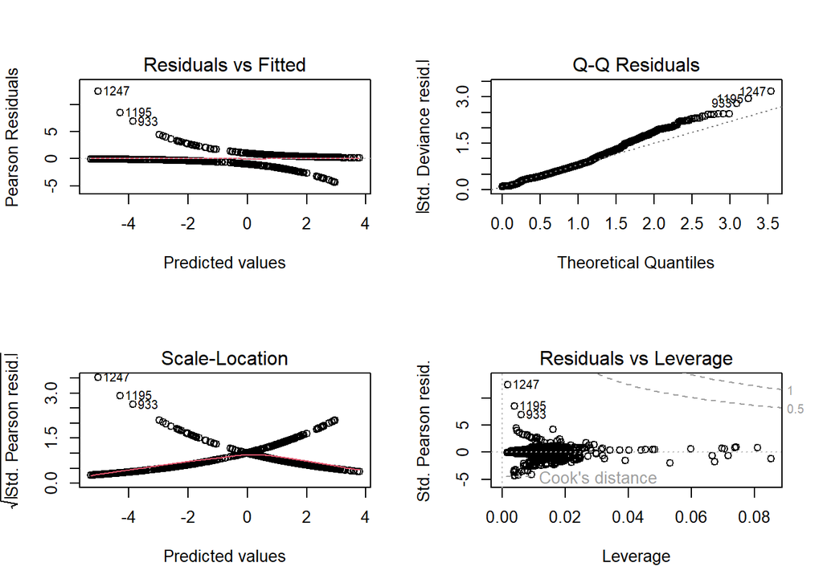

```r
# 模型诊断图
par(mfrow = c(2, 2))
plot(fit_multi_logit)
```

```r
par(mfrow = c(1, 1))
```

## 6 6. 结论与局限

**结论**：科技行业从业者的心理健康求助行为受工作干扰程度、家族史、性别、公司福利和关怀选项的显著影响。年龄在单因素分析中显著，但在多因素模型中不再显著，提示其作用可能被其他因素（如工作干扰）混杂。

**局限**：本研究为横截面数据，不能推断因果关系。数据存在自我报告偏倚。此外，模型中包含部分未知/不确定的回答，这可能会对结果产生一定影响。